# Assignment 4

QAC356

Due Nov 18th

In assignment 4 you’ll take the *ryx* function and turn it into a full-fledged object oriented (S3) package.

1. Create a local R package project called rxy. Place it under git version control.
2. Start with the following version of the ryx function.

```r
ryx <- function(data, y, x){
  if(missing(x)){
    x <- names(data)[sapply(data, class)=="numeric"]
    x <- setdiff(x, y)
  }
  df <- data.frame()
  for (var in x){
    res <- cor.test(data[[y]], data[[var]])
    df_temp <- data.frame(variable = var,
                       r = res$estimate,
                       p = res$p.value)
    df <- rbind(df, df_temp)
    df <- df[order(-abs(df$r)),]
  }

  df$sigif <- ifelse(df$p < .001, "***",
                    ifelse(df$p < .01, "**",
                    ifelse(df$p < .05, "*", " ")))
  results <- list(y=y, x=x, df=df)
  class(results) <- "ryx"
  return(results)
}
```

Add generic **print**, **plot**, and **summary** functions to support it.

Given

```r
library(MASS)
x <- ryx(Boston, y="medv")
```

your functions should reproduce the following output *as closely as possible*.

3. **print(x)**

```
Correlations of medv with
 variable      r        p sigif
    lstat -0.738  < 2e-16   ***
       rm  0.695  < 2e-16   ***
  ptratio -0.508  < 2e-16   ***
    indus -0.484  < 2e-16   ***
      tax -0.469  < 2e-16   ***
      nox -0.427  < 2e-16   ***
     crim -0.388  < 2e-16   ***
      age -0.377  < 2e-16   ***
       zn  0.360  < 2e-16   ***
    black  0.333 1.32e-14   ***
      dis  0.250 1.21e-08   ***
```

4. **summary(x)**

```
Correlating medv with crim zn indus nox rm age dis tax ptratio black lstat
The median absolute correlation was 0.427 with a range from -0.738 to 0.695
 11 out of 11 variables where significant at the p < 0.05 level.
```

5. **plot(x)**

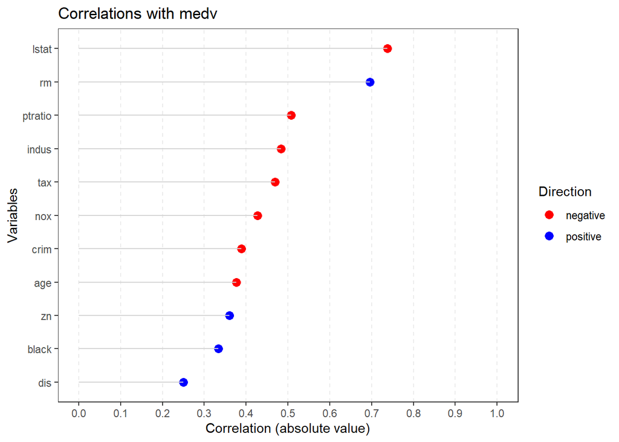

6. Add complete roxygen2 documentation to your functions. Be sure to include at least one example for each function.
7. Update the **DESCRIPTION** file.
8. Add a vignette demonstrating the use of the package.
9. Build the package.
10. Check the package using the **check** function and fix any errors (don’t worry about notes and warnings for now.)
11. Create a **README.md** file.
12. Use pkgdown to build the website documentation. Include a nice image to make the website interesting.
13. Commit project changes (git).
14. Create an **rxy** repository on git and push your local results to it.
15. Modify the repository GitHub Pages settings so that your support website is available.
16. **Submit the URL for your website.**